# Analysis of full-moon-er-admissions data

This program reads data on admissions to an emergency room before, during, and after a full moon. Find more information in the [data dictionary](https://github.com/pmean/data/blob/master/files/full-moon-er-admissions.yaml).

This code was written by Steve Simon on 2024-11-02 and is placed in the public domain.

## Load the tidyverse library

```r
library(broom)
library(tidyverse)
```

#### Comments on the code

For most of your programs, you should load the tidyverse library. The broom library converts your output to a nicely arranged dataframe. The messages and warnings are suppressed.

## Read the data and view a brief summary

```r
er <- read_tsv(
  "../data/full-moon-er-admissions.txt",
  col_types="ccn",
  col_names=TRUE)
names(er) <- tolower(names(er))
glimpse(er)
```

```
Rows: 36
Columns: 3
$ month     <chr> "Aug", "Sep", "Oct", "Nov", "Dec", "Jan", "Feb", "Mar", "Apr…
$ moon      <chr> "Before", "Before", "Before", "Before", "Before", "Before", …
$ admission <dbl> 6.4, 7.1, 6.5, 8.6, 8.1, 10.4, 11.5, 13.8, 15.4, 15.7, 11.7,…
```

#### Comments on the code

This is a tab delimited file. I changed all the variable names to all lowercase. That’s one less thing opportunity for inconsistency errors.

## Reorder the category levels, 1

```r
er$moon1 <- factor(
  er$moon,
  levels=c(
    "Before",
    "During",
    "After"))
```

#### Comments on the code

If you let R order the categories, it will do it alphabetically. The factor function will place them in a more logical order.

## Reorder the category levels, 2

```r
er$month1 <- factor(
  er$month,
  levels=c(
    "Aug", "Sep", "Oct",
    "Nov", "Dec", "Jan",
    "Feb", "Mar", "Apr",
    "May", "Jun", "Jul"))
```

#### Comments on the code

Since the study started in August, it makes sense to order the months starting then. An alphabetical ordering (April first then August?) makes no sense here.

## Draw boxplot of admission versus moon

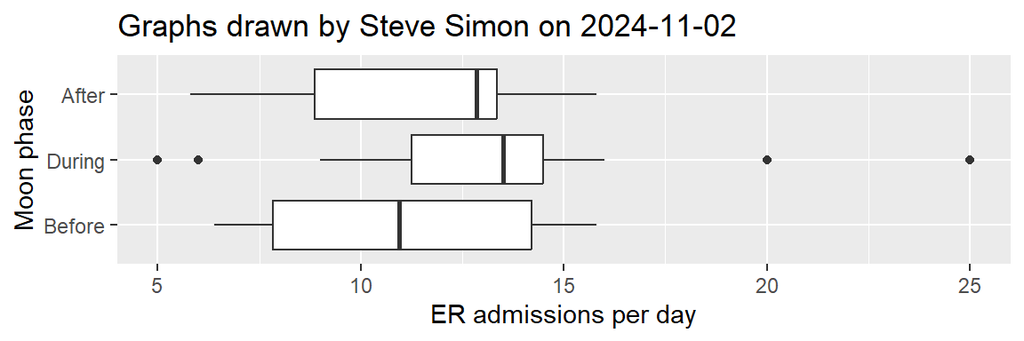

```r
er |>
  ggplot(aes(moon1, admission)) +
    geom_boxplot() +
    xlab("Moon phase") +
    ylab("ER admissions per day") +
    ggtitle("Graphs drawn by Steve Simon on 2024-11-02") +
    coord_flip()
```

#### Interpretation of the output

Although there are a few outliers, I would not worry too much about the normality assumption. It also looks like heterogeneity would not be too much of a concern.

## Draw boxplot of admission versus month

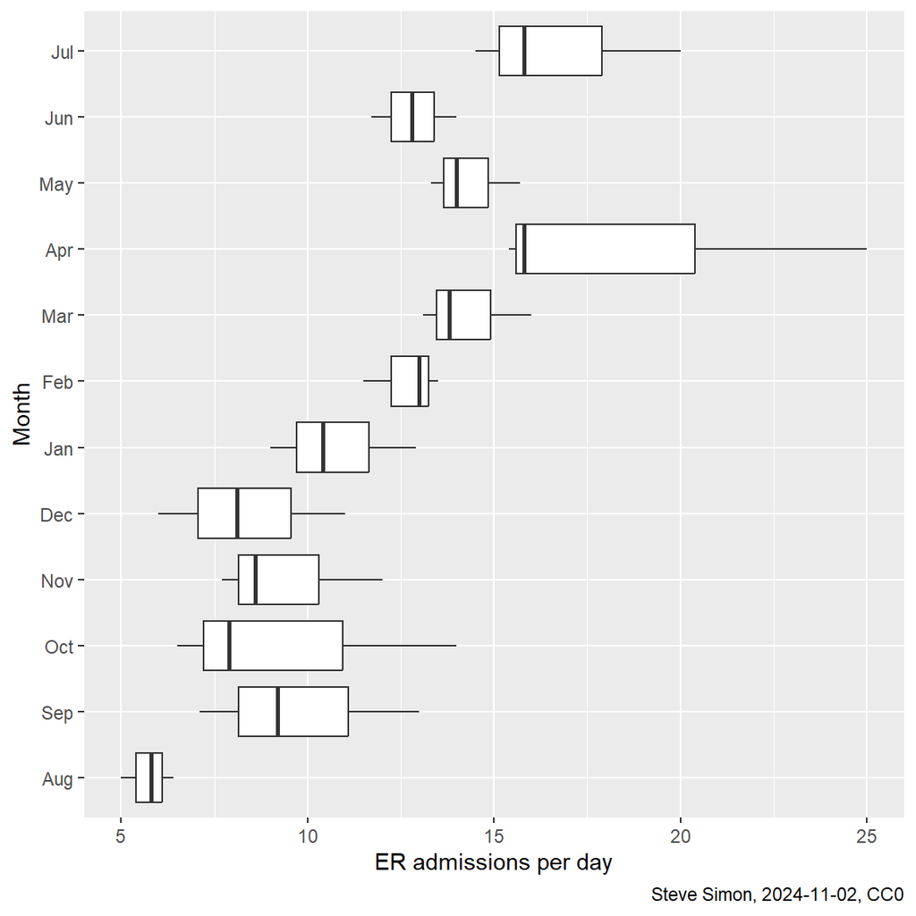

```r
er |>
  ggplot(aes(admission, month1)) +
    geom_boxplot() +
      labs(
        x="ER admissions per day",
        y="Month",
        caption="Steve Simon, 2024-11-02, CC0")
```

## Calculate average ER admissions versus moon

```r
er |>
  group_by(moon1) |>
  summarize(
    admission_mn=mean(admission),
    admission_sd=sd(admission),
    n=n())
```

```
# A tibble: 3 × 4
  moon1  admission_mn admission_sd     n
  <fct>         <dbl>        <dbl> <int>
1 Before         10.9         3.62    12
2 During         13.4         5.50    12
3 After          11.5         3.11    12
```

#### Interpretation of the output

There is a slightly higher average admission rate and slightly more vaiation during a full moon.

## Calculate average ER admissions versus month

```r
er |>
  group_by(month1) |>
  summarize(
    admission_mn=mean(admission),
    admission_sd=sd(admission),
    n=n())
```

```
# A tibble: 12 × 4
   month1 admission_mn admission_sd     n
   <fct>         <dbl>        <dbl> <int>
 1 Aug            5.73        0.702     3
 2 Sep            9.77        2.99      3
 3 Oct            9.47        3.99      3
 4 Nov            9.43        2.27      3
 5 Dec            8.37        2.51      3
 6 Jan           10.8         1.98      3
 7 Feb           12.7         1.04      3
 8 Mar           14.3         1.51      3
 9 Apr           18.7         5.43      3
10 May           14.3         1.23      3
11 Jun           12.8         1.15      3
12 Jul           16.8         2.87      3
```

#### Interpretation of the output

Er admissions are trending upward over time and there is some evidence of heterogeneity. Again, treat this with caution as there are only three observations per month.

## Analysis of variance

```r
m1 <- aov(admission ~ moon1 + month1, data=er)
anova(m1)
```

```
Analysis of Variance Table

Response: admission
          Df Sum Sq Mean Sq F value    Pr(>F)
moon1      2  41.51  20.757  3.5726   0.04533 *
month1    11 455.58  41.417  7.1285 5.076e-05 ***
Residuals 22 127.82   5.810
---
Signif. codes:  0 '***' 0.001 '**' 0.01 '*' 0.05 '.' 0.1 ' ' 1
```

#### Interpretation of the output

There is a borderline, but statistically significant difference in average admission rates during different phases of the moon. There is a statistically significant difference in average admission rates between some of the months.

## Using lm, 1

```r
m2 <- lm(admission ~ moon1 + month1, data=er)
anova(m2)
```

```
Analysis of Variance Table

Response: admission
          Df Sum Sq Mean Sq F value    Pr(>F)
moon1      2  41.51  20.757  3.5726   0.04533 *
month1    11 455.58  41.417  7.1285 5.076e-05 ***
Residuals 22 127.82   5.810
---
Signif. codes:  0 '***' 0.001 '**' 0.01 '*' 0.05 '.' 0.1 ' ' 1
```

#### Interpretation of the output

The analysis of variance table using lm is the same as the analysis of variance table using aov.

## Using lm, 2

```r
tidy(m2)
```

```
# A tibble: 14 × 5
   term        estimate std.error statistic    p.value
   <chr>          <dbl>     <dbl>     <dbl>      <dbl>
 1 (Intercept)    4.72      1.50      3.14  0.00476
 2 moon1During    2.5       0.984     2.54  0.0186
 3 moon1After     0.542     0.984     0.550 0.588
 4 month1Sep      4.03      1.97      2.05  0.0525
 5 month1Oct      3.73      1.97      1.90  0.0710
 6 month1Nov      3.70      1.97      1.88  0.0734
 7 month1Dec      2.63      1.97      1.34  0.195
 8 month1Jan      5.03      1.97      2.56  0.0180
 9 month1Feb      6.93      1.97      3.52  0.00192
10 month1Mar      8.57      1.97      4.35  0.000255
11 month1Apr     13.0       1.97      6.61  0.00000121
12 month1May      8.60      1.97      4.37  0.000245
13 month1Jun      7.10      1.97      3.61  0.00156
14 month1Jul     11.0       1.97      5.61  0.0000123
```

#### Interpretation of the output

The intercept represents the estimated average admission rate before a full moon and during the month of August. The admission rate is 2.5 patients per day higher during a full moon compared to a full moon. This is small but probably still important. The difference in average admission rates is 0.54 patients per day higher after a full moon compared to before a full moon. The remaining estimates compare each month back to the first month (August).

## Using lm, 3

```r
er |>
  group_by(moon1) |>
  summarize(admission_mn=mean(admission)) |>
  mutate(admission_before=first(admission_mn)) |>
  mutate(difference=admission_mn-admission_before)
```

```
# A tibble: 3 × 4
  moon1  admission_mn admission_before difference
  <fct>         <dbl>            <dbl>      <dbl>
1 Before         10.9             10.9      0
2 During         13.4             10.9      2.5
3 After          11.5             10.9      0.542
```

#### Comments on the code

This table shows how to calculate the regression coefficients associated with phases of the moon. It is not really needed for the analysis, but helps illustrate how these coefficients are computed.

## Using lm, 4

```r
er |>
  group_by(month1) |>
  summarize(admission_mn=mean(admission)) |>
  mutate(admission_aug=first(admission_mn)) |>
  mutate(difference=admission_mn-admission_aug)
```

```
# A tibble: 12 × 4
   month1 admission_mn admission_aug difference
   <fct>         <dbl>         <dbl>      <dbl>
 1 Aug            5.73          5.73       0
 2 Sep            9.77          5.73       4.03
 3 Oct            9.47          5.73       3.73
 4 Nov            9.43          5.73       3.7
 5 Dec            8.37          5.73       2.63
 6 Jan           10.8           5.73       5.03
 7 Feb           12.7           5.73       6.93
 8 Mar           14.3           5.73       8.57
 9 Apr           18.7           5.73      13
10 May           14.3           5.73       8.6
11 Jun           12.8           5.73       7.1
12 Jul           16.8           5.73      11.0
```

#### Comments on the code

This table shows how to calculate the regression coefficients associated with months of the year.

## Save important files for later use

```r
save(
  er,
  file="../data/full-moon-er-admissions.RData")
```